# blatt02

$$\textbf{Blatt 02 - Praktische Optimierung - Adrian Lentz, Robert}$$

Lösungen und Erklärungen für Blatt 02. $$\newline$$ Adrian Lentz - Matrikelnummer: 258882 $$\newline$$ Robert Schönewald - Matrikelnummer: 188252

```python
#Pakete importieren
import numpy as np
import matplotlib.pyplot as plt
from scipy import optimize
from inspect import signature
import plotly.graph_objects as go
```

$$\textbf{Aufgabe 2.1}$$

```python
x=np.linspace(-10,10)

x_0=0                           #Startwert
def f_1(x):                     #Definiert Funktion f_1(x)
    return (x+5)**2

def f_2(x):                     #Definiert Funktion f_2(x)
    return (x+3)**2 - 5*np.cos(5*x)


'''
#Scalarer Optimierer mit Brent-Algo.
res=optimize.minimize_scalar(f_1)
print(res)  --> Gibt gleiches Ergebniss aus
'''


#Minimierung mithilfe von "Brent"
minimizer_brent_f_1 = optimize.brent(f_1, brack=(-10,10),full_output=True) #Brack: If bracket consists of two numbers (a,c) then they are assumed to be a starting interval for a downhill bracket search
minimizer_brent_f_2 = optimize.brent(f_2, brack=(-10,10),full_output=True) #Brack legt Start Bereich zwischen (a,c) der Suche fest
#Output : (a,b,c,d) mit a=xmin , b=f(xmin) , c=Anzahl der Iterationen , d=Anzahl der Funktionsbewertungen

print(f'Minimierung der Funktion f_1(x) mithilfe von "Brent"-Algrithmus: Optimum bei x={minimizer_brent_f_1[0]} und dem Funktionswert f(x)={minimizer_brent_f_1[1]}' )
print(f'Minimierung der Funktion f_2(x) mithilfe von "Brent"-Algrithmus: Optimum bei x={minimizer_brent_f_2[0]} und dem Funktionswert f(x)={minimizer_brent_f_2[1]}' )

#Minimierung mithilfe von "BFGS"
minimizer_BFGS_f_1= optimize.minimize(f_1,x_0,method='BFGS')  #Startwert x_0
minimizer_BFGS_f_2= optimize.minimize(f_2,x_0,method='BFGS')  #Startwert x_0
#Ausgabe f_1
Ausgabe_BFGS_f_1=minimizer_BFGS_f_1
Ausgabe_BFGS_f_1_x_wert= str(Ausgabe_BFGS_f_1.x).strip('[]')
Ausgabe_BFGS_f_1_f_werte=Ausgabe_BFGS_f_1.fun

#Ausgabe f_2
Ausgabe_BFGS_f_2=minimizer_BFGS_f_2
Ausgabe_BFGS_f_2_x_wert= str(Ausgabe_BFGS_f_2.x).strip('[]')
Ausgabe_BFGS_f_2_f_werte=Ausgabe_BFGS_f_2.fun

print(f'Minimierung der Funktion f_1(x) mithilfe von "BFGS"-Algrithmus: Optimum bei x={Ausgabe_BFGS_f_1_x_wert} und dem Funktionswert f(x)={Ausgabe_BFGS_f_1.fun}' )
print(f'Minimierung der Funktion f_2(x) mithilfe von "BFGS"-Algrithmus: Optimum beix={Ausgabe_BFGS_f_2_x_wert} und dem Funktionswert f(x)={Ausgabe_BFGS_f_2.fun}' )

'''
Erklärungsabschnitt zum eigenen Verständnis über BFGS:
BFGS nutzt 2.Ableitung, um Optimum zu finden --> Mithilfe von Inverser Hesse-Matrix --> (n x n) - Näherungen gespeichert mit n=Anzahl Variablen  , Line-Search in bestimmte Richtung
'''

#Minimierung mithilfe von "L-BFGS-B"
minimizer_L_BFGS_B_f_1= optimize.minimize(f_1,x_0,method='L-BFGS-B')  #Startwert x_0
minimizer_L_BFGS_B_f_2= optimize.minimize(f_2,x_0,method='L-BFGS-B')  #Startwert x_0
#Ausgabe
Ausgabe_L_BFGS_f_1=minimizer_L_BFGS_B_f_1
Ausgabe_L_BFGS_f_1_x_wert= str(Ausgabe_L_BFGS_f_1.x).strip('[]')
Ausgabe_L_BFGS_f_2=minimizer_L_BFGS_B_f_2
Ausgabe_L_BFGS_f_2_x_wert= str(Ausgabe_L_BFGS_f_2.x).strip('[]')

print(f'Minimierung der Funktion f_1(x) mithilfe von "L-BFGS-B"-Algrithmus: Optimum bei x={Ausgabe_L_BFGS_f_1_x_wert} und dem Funktionswert f(x)={Ausgabe_L_BFGS_f_1.fun}' )
print(f'Minimierung der Funktion f_2(x) mithilfe von "L-BFGS-B"-Algrithmus: Optimum bei x={Ausgabe_L_BFGS_f_2_x_wert} und dem Funktionswert f(x)={Ausgabe_L_BFGS_f_2.fun}' ) #Wert unterschiedlich ?




#Erklärungsabschnitt zum eigenen Verständnis über L-BFGS-B:
#Limited-memory BFGS: Analog zu BFGS --> Mithilfe von Inverser Hesse-Matrix --> Nur wenige Vektoren gespeichert --> Linearer Speicher
```

```
Minimierung der Funktion f_1(x) mithilfe von "Brent"-Algrithmus: Optimum bei x=-5.0 und dem Funktionswert f(x)=0.0
Minimierung der Funktion f_2(x) mithilfe von "Brent"-Algrithmus: Optimum bei x=-2.5209409400751377 und dem Funktionswert f(x)=-4.766829111587686
Minimierung der Funktion f_1(x) mithilfe von "BFGS"-Algrithmus: Optimum bei x=-5.00000003 und dem Funktionswert f(x)=6.914540208852864e-16
Minimierung der Funktion f_2(x) mithilfe von "BFGS"-Algrithmus: Optimum beix=-2.52094096 und dem Funktionswert f(x)=-4.766829111587682
Minimierung der Funktion f_1(x) mithilfe von "L-BFGS-B"-Algrithmus: Optimum bei x=-4.99999954 und dem Funktionswert f(x)=2.0772310584811207e-13
Minimierung der Funktion f_2(x) mithilfe von "L-BFGS-B"-Algrithmus: Optimum bei x=-4.99449928 und dem Funktionswert f(x)=-0.9579138626591672
```

$$\textbf{Erklärung}$$

Brent-Algorithmus ist zur Bestimmung der Nullstelle, mithilfe einer Bisektion (Iterationssverfahren).

BFGS ist ein Abstiegsverfahren, welches die 2.Ableitungen nutzt, um ein Optimum zu finden. Dabei wird die inverse Hesse-Matrix gelöst, um eine initalen Start zu ermöglichen. $\$ L-BFGS-B ist ein Speicher limitierder Algorithmus basierend auf BFGS, sodass dieser ein unterschiedliches Ergebniss produzieren kann. So ist die Minimierung von Funktion f_1(x) fast gleich, jedoch nicht für Funktion f_2(x).

$$\textbf{Aufgabe 2.2}$$

Informationen x = x-Wert , Start x_start s = Schrittweite , Start s_start k = Iterationszahl (iters) theta = Faktor zwischen (0,1) --> s(k+1)=theta * s(k) : d = Richtung mit : Es existiert mindestens ein d aus D D = Einheitsvektoren (positiv/negativ) für n Dimensionen

```python
'Funktionen definieren'

def f_a(x):
    return (x+5)**2

def f_b(x):
    return (x+3)**2 - 5*np.cos(5*x)

def f_c(x,y):
    return x**2 + y**2

def f_d(x,y):
    return x*np.sin(x) + 3*(y**2)
```

```python
'Definiert Kompasssuche'
def kompasssuche(f,x0,s0,theta,iters,showit=False,getpath=False): #Alle Parameter wie in Aufgabe gewünscht mit 2 zusätzlichen optionalen Parametern,
    dim=len(signature(f).parameters)                              #showit um Anzahl der Iterationen zu printen, und getpath um ein Array des Weges zurückzugeben
    d=np.concatenate((np.identity(dim),np.negative(np.identity(dim))))
    if dim==1:             #Dimensionen unterschiedlich definiert, da es sonst später beim Plotten Schwierigkeiten gab
        path=[[x0,s0,f(x0)]]
        for k in range(0,iters):    #Definition der Kompasssuche
            f_old=f(x0)
            for d0 in d:
                f_current=f(x0 + s0 * d0)
                if f_current< f_old:
                    x0=x0+s0*d0
                    path.append([x0,s0,f_current])
                    break
                if d0 == d[-1]:
                    s0=theta*s0
        if showit:
            print("Iterationen: " + str(len(path)-1)+ ", \t Abstand zum Optimum: ",end = " ")
        if getpath:
            return path
        else:
            return x0
    else:
        path=[[x0,s0,f(x0[0],x0[1])]]
        for k in range(0,iters):
            f_old=f(x0[0],x0[1])
            for d0 in d:
                x1=x0 + s0 * d0
                f_current=f(x1[0],x1[1])
                if f_current < f_old:
                    x0=x0+s0*d0
                    path.append([x0,s0,f_current])
                    break
                if all(d0 == d[-1]):
                    s0=theta*s0
        if showit:
            print("Iterationen: " + str(len(path)-1)+ ", \t Abstand zum Optimum: ",end = " ")
        if getpath:
            return path
        else:
            return x0
```

```python
'Betrachte alle möglichen Kombinationen aller Parameter'
print(-5-kompasssuche(f_a,3,0.5,0.3,20,True))
print(-5-kompasssuche(f_a,9,0.5,0.3,20,True))
print(-5-kompasssuche(f_a,3,4,0.3,20,True))
print(-5-kompasssuche(f_a,9,4,0.3,20,True))
print(-5-kompasssuche(f_a,3,0.5,0.8,20,True))
print(-5-kompasssuche(f_a,9,0.5,0.8,20,True))
print(-5-kompasssuche(f_a,3,4,0.8,20,True))
print(-5-kompasssuche(f_a,9,4,0.8,20,True))
print("Wähle für f_a die Parameter 3, 4, 0.3 für jeweils x0, s0 und theta \n")  #Auswahl aufgrund vom Abstand zum Optimum und Iterationsanzahl

print(2.521-kompasssuche(f_b,3,0.5,0.3,20,True))
print(2.521-kompasssuche(f_b,9,0.5,0.3,20,True))
print(2.521-kompasssuche(f_b,3,4,0.3,20,True))
print(2.521-kompasssuche(f_b,9,4,0.3,20,True))
print(2.521-kompasssuche(f_b,3,0.5,0.8,20,True))
print(2.521-kompasssuche(f_b,9,0.5,0.8,20,True))
print(2.521-kompasssuche(f_b,3,4,0.8,20,True))
print(2.521-kompasssuche(f_b,9,4,0.8,20,True))
print("Wähle für f_b die Parameter 3, 0.5, 0.8 für jeweils x0, s0 und theta \n")

print(np.linalg.norm(kompasssuche(f_c,[3,3],0.5,0.3,20,True)))
print(np.linalg.norm(kompasssuche(f_c,[9,9],0.5,0.3,20,True)))
print(np.linalg.norm(kompasssuche(f_c,[3,3],4,0.3,20,True)))
print(np.linalg.norm(kompasssuche(f_c,[9,9],4,0.3,20,True)))
print(np.linalg.norm(kompasssuche(f_c,[3,3],0.5,0.8,20,True)))
print(np.linalg.norm(kompasssuche(f_c,[9,9],0.5,0.8,20,True)))
print(np.linalg.norm(kompasssuche(f_c,[3,3],4,0.8,20,True)))
print(np.linalg.norm(kompasssuche(f_c,[9,9],4,0.8,20,True)))
print("Wähle für f_c die Parameter (3,3), 0.5, 0.3 für jeweils x0, s0 und theta \n")

print(np.linalg.norm(kompasssuche(f_d,[3,3],0.5,0.3,20,True)-(4.71,0)))
print(np.linalg.norm(kompasssuche(f_d,[9,9],0.5,0.3,20,True)-(4.71,0)))
print(np.linalg.norm(kompasssuche(f_d,[3,3],4,0.3,20,True)-(4.71,0)))
print(np.linalg.norm(kompasssuche(f_d,[9,9],4,0.3,20,True)-(4.71,0)))
print(np.linalg.norm(kompasssuche(f_d,[3,3],0.5,0.8,20,True)-(4.71,0)))
print(np.linalg.norm(kompasssuche(f_d,[9,9],0.5,0.8,20,True)-(4.71,0)))
print(np.linalg.norm(kompasssuche(f_d,[3,3],4,0.8,20,True)-(4.71,0)))
print(np.linalg.norm(kompasssuche(f_d,[9,9],4,0.8,20,True)-(4.71,0)))
print("Wähle für f_d die Parameter (3,3), 0.5, 0.8 für jeweils x0, s0 und theta \n")
```

```
Iterationen: 16, 	 Abstand zum Optimum:  [0.]
Iterationen: 20, 	 Abstand zum Optimum:  [-4.]
Iterationen: 2, 	 Abstand zum Optimum:  [0.]
Iterationen: 11, 	 Abstand zum Optimum:  [-6.79999994e-08]
Iterationen: 16, 	 Abstand zum Optimum:  [0.]
Iterationen: 20, 	 Abstand zum Optimum:  [-4.]
Iterationen: 2, 	 Abstand zum Optimum:  [0.]
Iterationen: 10, 	 Abstand zum Optimum:  [0.21116662]
Wähle für f_a die Parameter 3, 4, 0.3 für jeweils x0, s0 und theta

Iterationen: 10, 	 Abstand zum Optimum:  [0.097487]
Iterationen: 13, 	 Abstand zum Optimum:  [-2.3690995]
Iterationen: 10, 	 Abstand zum Optimum:  [5.04195037]
Iterationen: 11, 	 Abstand zum Optimum:  [5.04197655]
Iterationen: 7, 	 Abstand zum Optimum:  [0.08428534]
Iterationen: 12, 	 Abstand zum Optimum:  [-2.4118256]
Iterationen: 4, 	 Abstand zum Optimum:  [6.27172]
Iterationen: 5, 	 Abstand zum Optimum:  [6.25828]
Wähle für f_b die Parameter 3, 0.5, 0.8 für jeweils x0, s0 und theta

Iterationen: 12, 	 Abstand zum Optimum:  0.0
Iterationen: 20, 	 Abstand zum Optimum:  8.0
Iterationen: 14, 	 Abstand zum Optimum:  0.004355777772109083
Iterationen: 15, 	 Abstand zum Optimum:  0.013165348457219006
Iterationen: 12, 	 Abstand zum Optimum:  0.0
Iterationen: 20, 	 Abstand zum Optimum:  8.0
Iterationen: 10, 	 Abstand zum Optimum:  0.23841390591264072
Iterationen: 10, 	 Abstand zum Optimum:  0.36898619408256955
Wähle für f_c die Parameter (3,3), 0.5, 0.3 für jeweils x0, s0 und theta

Iterationen: 15, 	 Abstand zum Optimum:  0.20376499999999975
Iterationen: 20, 	 Abstand zum Optimum:  6.368995211177349
Iterationen: 14, 	 Abstand zum Optimum:  0.20225945242682733
Iterationen: 14, 	 Abstand zum Optimum:  0.20176406665211793
Iterationen: 13, 	 Abstand zum Optimum:  0.15237439999999935
Iterationen: 20, 	 Abstand zum Optimum:  6.368995211177349
Iterationen: 11, 	 Abstand zum Optimum:  0.5485688868323073
Iterationen: 8, 	 Abstand zum Optimum:  0.3088662746328251
Wähle für f_d die Parameter (3,3), 0.5, 0.8 für jeweils x0, s0 und theta
```

```
[[3, 4, 64], [array([-1.]), 4, array([16.])], [array([-5.]), 4, array([0.])]]
```

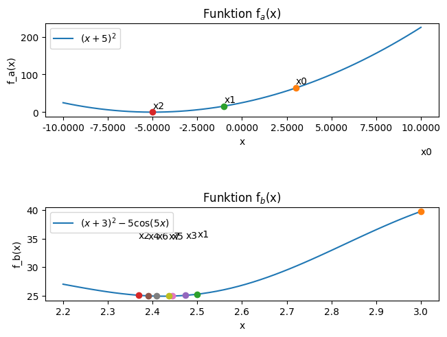

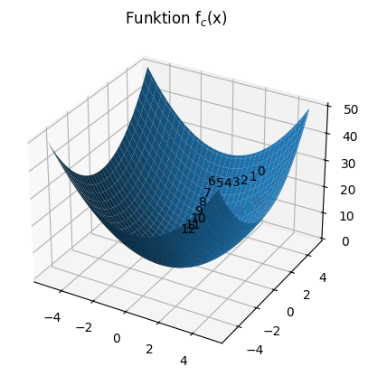

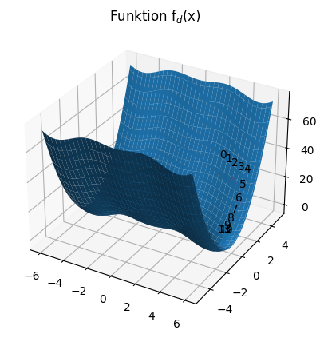

```python
'Plotten aller Funktionen mit dem jeweiligen Weg der ausgewählten Kompasssuche'

x=np.linspace(-10,10)
y=np.linspace(-10,10)


fig, (ax1,ax2) = plt.subplots(2,1, layout= "constrained")
#Graph für Funktion f_a(x)

ax1.set_title("Funktion f$_{a}$(x)")
ax1.set_xlabel("x")
ax1.set_ylabel("f_a(x)")
#setup(ax1, title="StrMethodFormatter('{x:.3f}')")
ax1.xaxis.set_major_formatter(ticker.StrMethodFormatter("{x:.4f}"))
ax1.plot(x, f_a(x), label=r"$(x+5)^{2}$");
path_a=kompasssuche(f_a,3,4,0.3,20,False,True)
k=0
print(path_a)
for j in path_a:
    ax1.plot(j[0],j[2],"o");
    ax1.text(j[0],j[2]+10,"x{}".format(k))
    k=k+1
ax1.legend()

#Graph für Funktion f_2(x)
x=np.linspace(2.2,3)
ax2.set_title("Funktion f$_{b}$(x)")
ax2.set_xlabel("x")
ax2.set_ylabel("f_b(x)")
ax2.plot(x, f_b(x), label=r"$(x+3)^{2} - 5\cos(5x)$");
path_b=kompasssuche(f_b,3,0.5,0.8,20,False,True)
k=0
for j in path_b:
    ax2.plot(j[0],j[2],"o");
    ax2.text(j[0],j[2]+10,"x{}".format(k))
    k=k+1
ax2.legend()

# Gitter zum Auswerten der Funktion erzeugen
x = np.linspace(-5, 5, 101)
y = np.linspace(-5, 5, 101)
X, Y = np.meshgrid(x, y)
Z = f_c(X,Y)
# 3D-Plot erzeugen: Out[87]: In [88]: In [89]:
fig = plt.figure()
ax3 = plt.axes(projection='3d')
ax3.set_title("Funktion f$_{c}$(x)")
ax3.plot_surface(X, Y, Z)
path_c=kompasssuche(f_c,[3,3],0.5,0.3,20,False,True)
k=0
for j in path_c:
    ax3.plot(j[0][0],j[0][1],j[2],"o");
    ax3.text(j[0][0],j[0][1],j[2]+10,"{}".format(k))
    k=k+1

# Gitter zum Auswerten der Funktion erzeugen
x = np.linspace(-6, 6, 101)
y = np.linspace(-5, 5, 101)
X, Y = np.meshgrid(x, y)
Z = f_d(X,Y)
# 3D-Plot erzeugen: Out[87]: In [88]: In [89]:
fig = plt.figure()
ax4 = plt.axes(projection='3d')
ax4.set_title("Funktion f$_{d}$(x)")
ax4.plot_surface(X, Y, Z)
path_d=kompasssuche(f_d,[3,3],0.5,0.8,20,False,True)
k=0
for j in path_d:
    ax4.plot(j[0][0],j[0][1],j[2],"o");
    ax4.text(j[0][0],j[0][1],j[2]+10,"{}".format(k))
    k=k+1

plt.show()
```

Interpretation der Ergebnisse:

In der ersten Funktion wurden Parameter zufälligerweise sehr passend gewählt, sodass die Kompasssuche schnell vorbei war. Die zweite Funktion war deutlich schwieriger zu optimieren, da der gesuchte Wert nicht rational war. Im Weg der dritten Funktion sieht man, welche Achse zuerst betrachtet wurde. Nachdem auf dieser jedoch keine Verbesserung in positiver Richtung möglich war, wurde auf der nächsten Achse weitergesucht, bis schließlich das Optimum gefunden wurde. In der vierten Funktion sieht man sehr ähnliches Verhalten, es gibt wieder einen "Knick" in eine andere Richtung, nachdem dies nötig wurde.